# HW 10 - Tim Demetriades

11/14/2021

### Part III

#### Use the posted VariationalAutoEncoder_demo.py file to testify the VAE.

#### 1. Repeat the posted VAE script to plot the newly generated images.

```python
# First, let’s implement the encoder net Q(z|X), which takes input X and outputting two things: μ(X) and Σ(X), the parameters of the Gaussian.

#from tensorflow.examples.tutorials.mnist import input_data
from tensorflow.keras.datasets import mnist
from tensorflow.keras.layers import Input, Dense, Lambda
from tensorflow.keras.models import Model
#from keras.objectives import binary_crossentropy
from tensorflow.keras.callbacks import LearningRateScheduler
from tensorflow.keras import metrics
```

```python
import numpy as np
import matplotlib.pyplot as plt
import tensorflow.keras.backend as K
import tensorflow as tf
```

```python
from tensorflow.python.framework.ops import disable_eager_execution
```

```python
disable_eager_execution()
```

```python
m = 100     # batch size
n_z = 2    # latent dimension
n_epoch = 10    # number of epochs for iterations
epsilon_std = 1.0
original_dim = 784
intermediate_dim = 256
```

```python
# Q(z|x) -> encoder
inputs = Input(batch_shape=(m, original_dim))
h_q = Dense(intermediate_dim, activation='relu')(inputs)

mu = Dense(n_z)(h_q)
log_sigma = Dense(n_z)(h_q)
```

```python
def sample_z(args):
    mu, log_sigma = args
    eps = K.random_normal(shape=(m, n_z), mean=0., stddev=epsilon_std)

    return mu + K.exp(log_sigma / 2) * eps
```

```python
# Sample z ~ Q(z|x)
z = Lambda(sample_z)([mu, log_sigma])
```

```python
# P(x|z) -> decoder
decoder_hidden = Dense(intermediate_dim, activation='relu')
decoder_out = Dense(original_dim, activation='sigmoid')

h_p = decoder_hidden(z)
outputs = decoder_out(h_p)
```

```python
def vae_loss(y_true, y_pred):
    # Calculate loss = reconstruction loss + KL loss for each data in minibatch
    # KL Loss = a measure of how one probability distribution is different from a second
    #recon = K.sum(K.binary_crossentropy(y_pred, y_true), axis=1)
    recon = original_dim * metrics.binary_crossentropy(y_true, y_pred)
    # D_KL(Q(z|X) || P(z|X)); calculate in closed form as both dist. are Gaussian
    #kl = 0.5 * K.sum(K.exp(log_sigma) + K.square(mu) - 1. - log_sigma, axis=1)
    kl = - 0.5 * K.sum(1 + log_sigma - K.square(mu) - K.exp(log_sigma), axis=-1)

    return recon + kl
```

```python
# Overall VAE model, for reconstruction and training
vae = Model(inputs, outputs)

# Encoder moder, to encode input into latent variable
# We use the mean as the output as it is the center point, the representative of the gaussian
encoder = Model(inputs, mu)

# Generative (decoder) model, generate new data given latent variable z
d_in = Input(shape=(n_z,))
d_h = decoder_hidden(d_in)
d_out = decoder_out(d_h)
generator = Model(d_in, d_out)
```

```python
(x_train, _), (x_test, y_test) = mnist.load_data()
```

```python
x_train = x_train.astype('float32') / 255.
x_test = x_test.astype('float32') / 255.
x_train = x_train.reshape((len(x_train), np.prod(x_train.shape[1:])))    # reshape to long vector
x_test = x_test.reshape((len(x_test), np.prod(x_test.shape[1:])))        # reshape to long vector
print(x_train.shape)
print(x_test.shape)
```

```
(60000, 784)
(10000, 784)
```

```python
vae.compile(optimizer='rmsprop', loss=vae_loss, experimental_run_tf_function=False)
vae.fit(x_train, x_train,
        batch_size=m,
        epochs=n_epoch,
        shuffle=True,
        validation_data=(x_test, x_test))
```

```
Train on 60000 samples, validate on 10000 samples
```

```
<keras.callbacks.History at 0x2508007bb80>
```

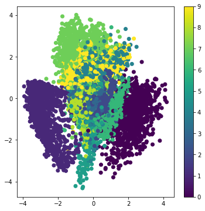

```python
x_test_encoded = encoder.predict(x_test, batch_size=m)
plt.figure(figsize=(6, 6))
plt.scatter(x_test_encoded[:, 0], x_test_encoded[:, 1], c=y_test)
plt.colorbar()
plt.show()
```

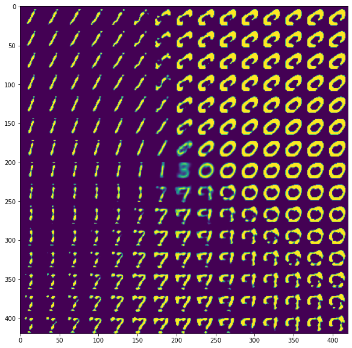

```python
# display a 2D manifold of the digits
n = 15  # figure with 15x15 digits
digit_size = 28
figure = np.zeros((digit_size * n, digit_size * n))
# we will sample n points within [-15, 15] standard deviations
grid_x = np.linspace(-15, 15, n)
grid_y = np.linspace(-15, 15, n)

for i, yi in enumerate(grid_x):
    for j, xi in enumerate(grid_y):
        z_sample = np.array([[xi, yi]]) * 2.0
        x_decoded = generator.predict(z_sample)
        digit = x_decoded[0].reshape(digit_size, digit_size)
        figure[i * digit_size: (i + 1) * digit_size,
               j * digit_size: (j + 1) * digit_size] = digit

plt.figure(figsize=(10, 10))
plt.imshow(figure)
plt.show()
```

#### 2. Modify the neural networks in the encoder and decoder layers and add one more layer with dimension 64 before the hidden factor n_z=2, i.e., the dimension reduction from 784->512->64->2.

#### See if the VAE outputs are improved or not.

```python
m = 100     # batch size
n_z = 2    # latent dimension
n_epoch = 10    # number of epochs for iterations
epsilon_std = 1.0
```

```python
# Q(z|x) -> encoder
inputs = Input(batch_shape=(m, 784))
h_q = Dense(512, activation='relu')(inputs)
h_q = Dense(64, activation='relu')(h_q)

mu = Dense(n_z)(h_q)
log_sigma = Dense(n_z)(h_q)
```

```python
# Sample z ~ Q(z|x)
z = Lambda(sample_z)([mu, log_sigma])
```

```python
# P(x|z) -> decoder
#decoder_hidden = Dense(64, activation='relu')
decoder_hidden = Dense(512, activation='relu')
decoder_out = Dense(784, activation='sigmoid')

h_p = decoder_hidden(z)
outputs = decoder_out(h_p)
```

```python
# Overall VAE model, for reconstruction and training
deep_vae = Model(inputs, outputs)

# Encoder moder, to encode input into latent variable
# We use the mean as the output as it is the center point, the representative of the gaussian
deep_encoder = Model(inputs, mu)

# Generative (decoder) model, generate new data given latent variable z
d_in = Input(shape=(n_z,))
d_h = decoder_hidden(d_in)
d_out = decoder_out(d_h)
deep_generator = Model(d_in, d_out)
```

```python
deep_vae.compile(optimizer='rmsprop', loss=vae_loss, experimental_run_tf_function=False)
deep_vae.fit(x_train, x_train,
             batch_size=m,
             epochs=n_epoch,
             shuffle=True,
             validation_data=(x_test, x_test))
```

```
Train on 60000 samples, validate on 10000 samples
```

```
<keras.callbacks.History at 0x2508afd4640>
```

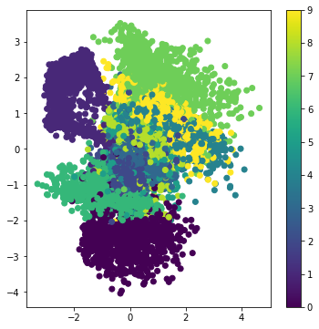

```python
x_test_encoded = deep_encoder.predict(x_test, batch_size=m)
plt.figure(figsize=(6, 6))
plt.scatter(x_test_encoded[:, 0], x_test_encoded[:, 1], c=y_test)
plt.colorbar()
plt.show()
```

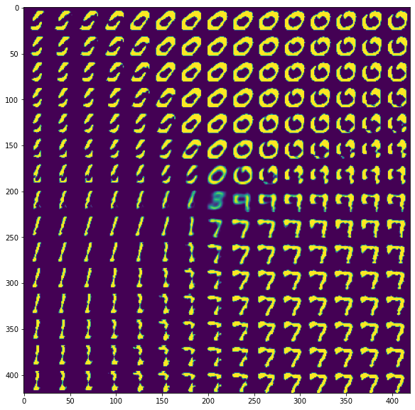

```python
# display a 2D manifold of the digits
n = 15  # figure with 15x15 digits
digit_size = 28
figure = np.zeros((digit_size * n, digit_size * n))
# we will sample n points within [-15, 15] standard deviations
grid_x = np.linspace(-15, 15, n)
grid_y = np.linspace(-15, 15, n)

for i, yi in enumerate(grid_x):
    for j, xi in enumerate(grid_y):
        z_sample = np.array([[xi, yi]]) * 2.0
        x_decoded = deep_generator.predict(z_sample)
        digit = x_decoded[0].reshape(digit_size, digit_size)
        figure[i * digit_size: (i + 1) * digit_size,
               j * digit_size: (j + 1) * digit_size] = digit

plt.figure(figsize=(10, 10))
plt.imshow(figure)
plt.show()
```

Here, we created two variational autoencoder - one with one hidden layer and another deeper one with two. We again are using the MNIST dataset to train the models on images of digits. After training, we make predictions on the test data and then plot a scatter plot of the predictions to show how the model was able to split up the data into 10 classes for the 10 different digits. A 2D manifold is also created with both models to generated images.

As can be seen, both models seem to produce similar results. Adding an extra hidden layer did not make a drastic improvement to the performance of the model. However, adding more epochs may produce better results.